# Resultados de alarmas

Jose Vicente Yago Martinez

16 September, 2020

Aqui se discute la seleccion de un cultivo para generar alarmas por temperaturas letales en el paper de invernaderos 4.0.

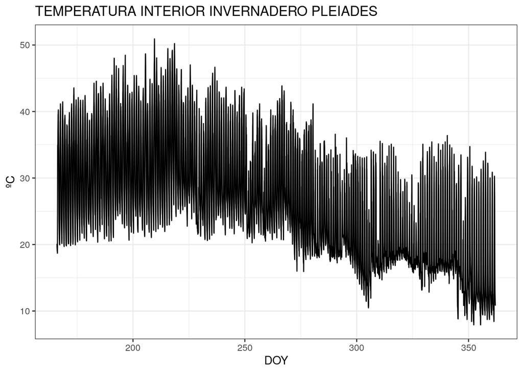

En el articulo propuesto por Alfonso se muestran las siguientes tablas de temperaturas:

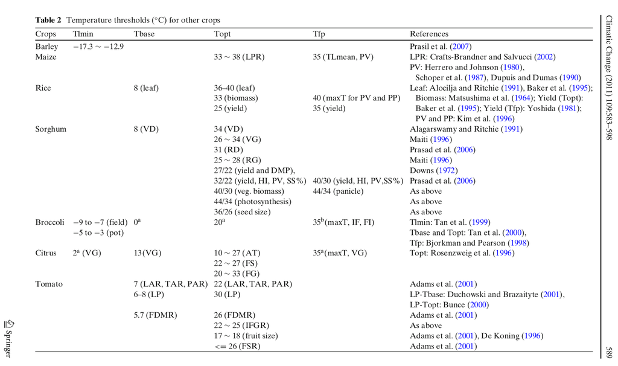

[figure not shown]

*Temperature thresholds and crop production: a review*, Qunying Luo Climatic Change (2011) 109:583–598, DOI 10.1007/s10584-011-0028-6

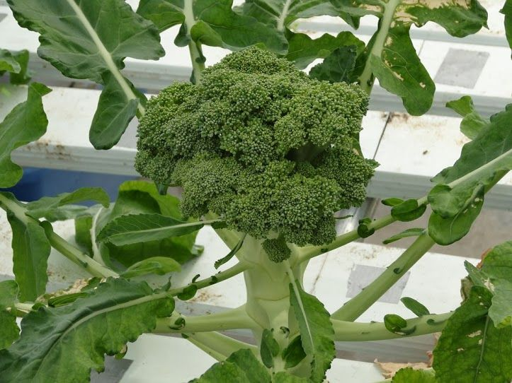

Me parece interesante el caso del brocoli puesto que es un vegetal que se cultiva durante todo el año, su *temperature failure point (tfp)* y temperatura maxima letal son razonablemente altas para dar “juego” con las alarmas por exceso de calor. Concretamente el *tfp* 35 ºC aprox. en la tabla anterior.

Lo siguientes parrafos han sido extraidos de otro articulo cientifico, que justifican un poco la decision del brocoli:

*[Broccoli] It is grown for both the fresh vegetable market and the processed food industry. The shelf-life of broccoli is short, excised florets spoiling within 2–3 days at room temperature (Paulsen et al., 2018). Thus, **broccoli crops are produced throughout the year** and are, therefore, grown under a wide range of environmental conditions (Wurr et al., 1991, 1995; Olesen, 1998; Tan et al., 2000a; Lindemann-Zutz et al., 2016ab) […] Broccoli crops are scheduled to meet consumer demand for both fresh vegetables and frozen foods. It is a continuous challenge for growers to meet the immediate demand for broccoli due to the un- predictability of crop development and head growth, but any inability to schedule crops appropriately presents a considerable financial risk (Lindemann-Zutz et al., 2016b).*

[…]

*The development of a broccoli plant consists of six phases: a germination phase, an emergence phase, a juvenile phase, a vegetative phase, a budding phase, and a heading phase (Huth et al., 2009). The vegetative phase is also referred to as the head induction phase and the budding and heading phases combined are referred to as the head growth phase. The head induction phase culminates in the phenological stage of head initiation and the beginning of the head growth phase. Broccoli has been reported to have a facultative (optional) vernalization response and head initiation can be observed even when grown at temperatures as high as 24−26 °C (Lindemann-Zutz et al., 2016a, and references therein). The juvenile phase, during which temperature has little effect on vernalization, is completed when plants have 3–5 leaves, which is the size at which broccoli plants are commonly transplanted to the field (Lindemann-Zutz et al., 2016a, and references therein). The optimum vernalisation temperature, defined as the temperature at which the intiation of heading is most rapid, is about 15−20 °C for most broccoli cultivars (Wurr et al., 1995; Fellows et al., 1997; Grevsen, 1998, 2000; Grevsen and Olesen, 1999; Lindemann-Zutz et al., 2016a). Plants require a longer thermal time, expressed as °C d, to head in- itiation if exposed to cooler or warmer temperatures than the optimum during growth and **no head initiation is expected at temperatures below 0 °C or above 25–30 °C***

*Predicting dates of head initiation and yields of broccoli crops grown throughout Scotland*, Davide Cammarano et al, European Journal of Agronomy 116 (2020) 12605, https://doi.org/10.1016/j.eja.2020.126055

Por todo lo explicado anteriormente he decido utilizar como **threshold** la temperatura de 35ºC (para ir en coherencia con las tablas).

# TEMPERATURA MÁXIMA LETAL

Recordemos que estamos tratando el caso de alarma semanal. Se lanza una alarma en una semana si la temperatura predicha ha superado el umbral maximo durante un tiempo mayor o igual a 1 hora. .

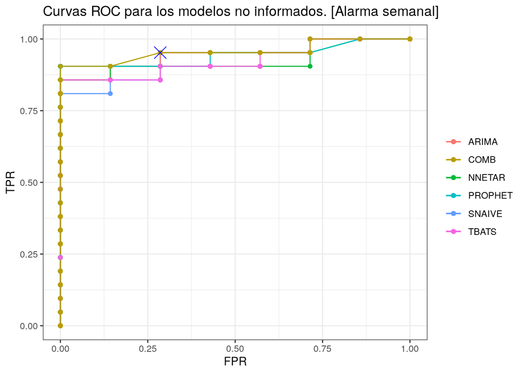

Una opción podría ser el valor de $\epsilon$ que genera el punto marcando con un aspa azul (COMB, $\epsilon = 4.0$).

|  | NO ALARM | ALARM |
| --- | --- | --- |
| **NO ALARM** | TNR = 0.71 | FPR = 0.28 |
| **ALARM** | FNR = 0.04 | TPR = 0.95 |

$$ACC = 0.9$$